# Metrics of the retrieved data

## Tenet

```python
import numpy as np
import pandas as pd
import matplotlib.pyplot as plt

df_tenet = pd.read_csv('/content/drive/Shareddrives/WebIntelligence/DATA/FILM_METRICS/TenetMetrics.csv')
df_tenet.set_index('platrofm', inplace=True, drop=True)
df_tenet = df_tenet.fillna(0)
df_tenet.head(7)
```

| platrofm | num_comments | compound_mean | compound_var | num_pos_com | num_neg_com | num_neu_com | pos_words/coms mean | pos_words/coms var | words_per_comment mean | neg_words/coms mean | neg_words/coms var |
| --- | --- | --- | --- | --- | --- | --- | --- | --- | --- | --- | --- |
| YouTube | 4751 | 0.146 | 0.227 | 2336 | 1241 | 1174 | 1.464 | 4.786 | 27.350 | 0.882 | 2.75 |
| Reddit | 497 | 0.067 | 0.272 | 229 | 172 | 96 | 2.100 | 13.028 | 44.200 | 1.570 | 6.87 |
| IMDB | 325 | 0.388 | 0.491 | 229 | 89 | 7 | 8.166 | 64.810 | 149.679 | 4.880 | 38.75 |

Taking into account the mean compound value of each chapter, we plot the mean and also the variance the values of all the retrieved tweets per episode. The variance is important, as could show up discrepancy in Twitter opinions.

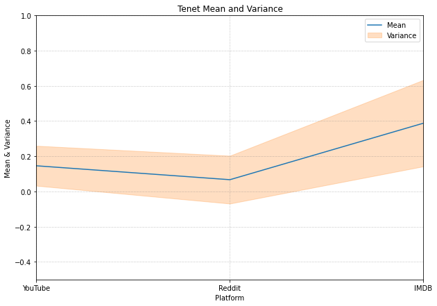

```python
labels = ['YouTube','Reddit','IMDB']

fig = plt.figure(figsize = (10,7))
y_tenet = df_tenet['compound_mean'].tolist()
var = df_tenet['compound_var'].tolist()
x = np.arange(0,3)
var_array = np.array(var)
error = var_array/2
plt.plot(x, y_tenet, label='Mean')
plt.fill_between(x, y_tenet-error, y_tenet+error, color='#ff7f0e', alpha=0.25, label='Variance')
plt.xlabel('Platform')
# plt.xticklabels(labels)
plt.ylabel('Mean & Variance')
plt.title('Tenet Mean and Variance')
plt.axis([0, 2, -0.5, 1])
plt.grid(linestyle='dotted', linewidth='0.5', color='grey')
plt.xticks([0,1,2], labels)
plt.legend()
plt.show()
```

Again, we see a more "extreme" behaviour for IMDB, with more variance. In this case, the film is better received in a more professional platform. This might be due to the fact that Tenet is a strange film, quite confusing, and maybe not for all publics.

Now we analyze the number of tweets per each "emotion" in each chapter.

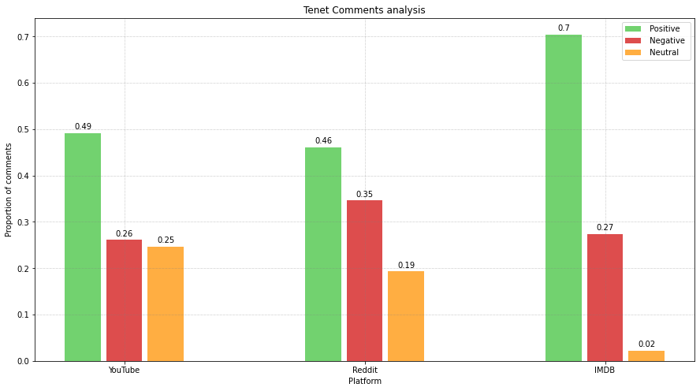

```python
labels = ['YouTube','Reddit','IMDB']
x = np.arange(len(labels))
num_tweets = df_tenet['num_comments'].to_numpy()
# pos_tweets is the real number
pos_tweets = df_tenet['num_pos_com'].to_numpy()
# pos_prop is the proportion (pos_tweets/all_tweets)
pos_prop = [i / j for i, j in zip(pos_tweets, num_tweets)]

neg_tweets = df_tenet['num_neg_com'].to_numpy()
neg_prop = [i / j for i, j in zip(neg_tweets, num_tweets)]

neu_tweets = df_tenet['num_neu_com'].to_numpy()
neu_prop = [i / j for i, j in zip(neu_tweets, num_tweets)]

fig, ax = plt.subplots()
fig.set_figheight(8)
fig.set_figwidth(15)
width = 0.15
pos_bar = ax.bar(x - width*1.15, pos_prop, width, color='#72D26F',label=' Positive ')
neg_bar = ax.bar(x ,  neg_prop,  width, color='#DD4D4D', label=' Negative ')
neu_bar = ax.bar(x + width*1.15,  neu_prop,  width, color='#FFAE42', label=' Neutral ')
ax.set_ylabel('Proportion of comments')
ax.set_xlabel('Platform')
ax.set_title('Tenet Comments analysis')
ax.set_xticks(x)
ax.set_xticklabels(labels)
ax.grid(linestyle='dotted', linewidth='0.5', color='grey')

ax.legend(loc='upper right')

def autolabel(rects):
    """Attach a text label above each bar in *rects*, displaying its height."""
    for rect in rects:
        height = rect.get_height()
        ax.annotate('{}'.format(float(round(height,2))),
                    xy=(rect.get_x() + rect.get_width() / 2, height),
                    xytext=(0, 3),  # 3 points vertical offset
                    textcoords="offset points",
                    ha='center', va='bottom')

autolabel(pos_bar)
autolabel(neg_bar)
autolabel(neu_bar)
```

The same way we have observed in the previous bar chart, we see how IMDB has so few neutral reviews, whilst these "missing" neutrals are divided inside positive and negative. Regarding Reddit and Youtube, we see similar behaviour.

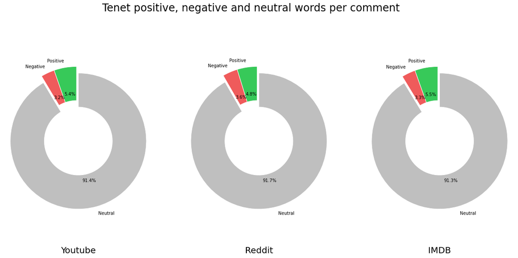

```python
labels = ['YouTube','Reddit','IMDB']
labels2 = ['Positive','Negative','Neutral']
num_words_per_comment = df_tenet['words_per_comment mean']

pos_words = df_tenet['pos_words/coms mean']
pos_proportion = [i / j for i, j in zip(pos_words, num_words_per_comment)]

neg_words = df_tenet['neg_words/coms mean']
neg_proportion = [i / j for i, j in zip(neg_words, num_words_per_comment)]

neu_proportion = [(1-(i + j)) for i, j in zip(pos_proportion, neg_proportion)]

sizes1 = [pos_proportion[0], neg_proportion[0], neu_proportion[0]] #Youtube
sizes2 = [pos_proportion[1], neg_proportion[1], neu_proportion[1]] #Reddit
sizes3 = [pos_proportion[2], neg_proportion[2], neu_proportion[2]] #IMDB

fig, (ax1, ax2, ax3) = plt.subplots(1, 3)
fig.set_figheight(9)
fig.set_figwidth(21)
fig.suptitle('Tenet positive, negative and neutral words per comment', fontsize=24)
explode = (0, 0, 0.1)
colors = ['#37C959','#EF5B5B','#bfbfbf']
hole_size = 0.5

ax1.pie(sizes1, explode=explode, labels=labels2, colors=colors, autopct='%1.1f%%',
        shadow=False, startangle=90, wedgeprops=dict(width=hole_size, edgecolor='w'))
ax1.axis('equal')# Equal aspect ratio ensures that pie is drawn as a circle.
ax1.set_xlabel('Youtube',fontsize=20)


ax2.pie(sizes2, explode=explode, labels=labels2,  colors=colors, autopct='%1.1f%%',
        shadow=False, startangle=90, wedgeprops=dict(width=hole_size, edgecolor='w'))
ax2.axis('equal')
ax2.set_xlabel('Reddit',fontsize=20)

ax3.pie(sizes3, explode=explode, labels=labels2,  colors=colors, autopct='%1.1f%%',
        shadow=False, startangle=90, wedgeprops=dict(width=hole_size, edgecolor='w'))
ax3.axis('equal')
ax3.set_xlabel('IMDB',fontsize=20)
```

For this film, there is aproximately the same proportion of positive/negative words per comment in all platforms. What remains constant from the previous film is the fact that YouTube has the bigger difference between the proportions of possitive and negative words per comment.

## The Irishman

```python
import numpy as np
import pandas as pd
import matplotlib.pyplot as plt

df_irishman = pd.read_csv('/content/drive/Shareddrives/WebIntelligence/DATA/FILM_METRICS/IrishmanMetrics.csv')
df_irishman.set_index('platrofm', inplace=True, drop=True)
df_irishman = df_irishman.fillna(0)
df_irishman.head(7)
```

| platrofm | num_comments | compound_mean | compound_var | num_pos_com | num_neg_com | num_neu_com | pos_words/coms mean | pos_words/coms var | words_per_comment mean | neg_words/coms mean | neg_words/coms var |
| --- | --- | --- | --- | --- | --- | --- | --- | --- | --- | --- | --- |
| YouTube | 3735 | 0.180 | 0.244 | 1909 | 941 | 885 | 1.508 | 4.590 | 23.67 | 0.770 | 2.09 |
| Reddit | 495 | 0.086 | 0.290 | 232 | 174 | 89 | 1.943 | 12.385 | 39.53 | 1.460 | 13.38 |
| IMDB | 325 | 0.263 | 0.480 | 210 | 113 | 2 | 7.790 | 94.993 | 154.48 | 5.157 | 45.56 |

Taking into account the mean compound value of each chapter, we plot the mean and also the variance the values of all the retrieved tweets per episode. The variance is important, as could show up discrepancy in Twitter opinions.

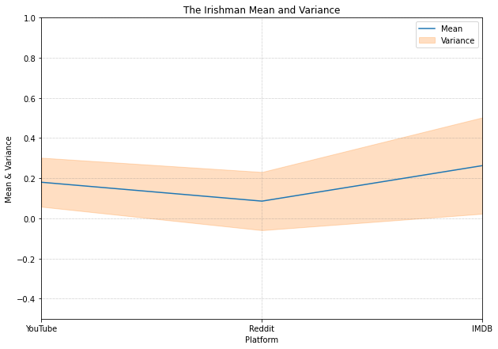

```python
labels = ['YouTube','Reddit','IMDB']

fig = plt.figure(figsize = (10,7))
y_irishman = df_irishman['compound_mean'].tolist()
var = df_irishman['compound_var'].tolist()
x = np.arange(0,3)
var_array = np.array(var)
error = var_array/2
plt.plot(x, y_irishman, label='Mean')
plt.fill_between(x, y_irishman-error, y_irishman+error, color='#ff7f0e', alpha=0.25, label='Variance')
plt.xlabel('Platform')
plt.ylabel('Mean & Variance')
plt.title('The Irishman Mean and Variance')
plt.grid(linestyle='dotted', linewidth='0.5', color='grey')
plt.axis([0, 2, -0.5, 1])
plt.xticks([0,1,2], labels)
plt.legend()
plt.show()
```

For The Irishman, the behaviour of the compound value mean and variance is the most stable along the study, being much more similar to the other platforms. It is true that the variance increases, but not so dramatically as in the rest of the films.

Now we analyze the number of tweets per each "emotion" in each chapter.

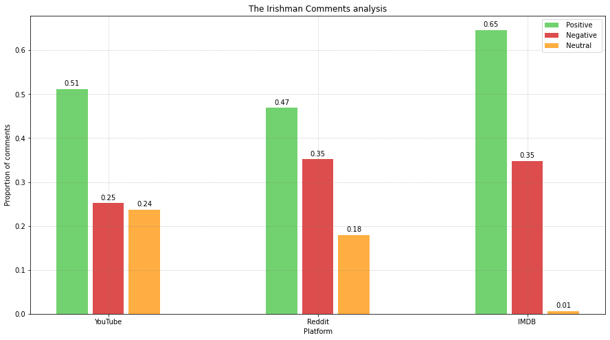

```python
labels = ['YouTube','Reddit','IMDB']
x = np.arange(len(labels))
num_tweets = df_irishman['num_comments'].to_numpy()
# pos_tweets is the real number
pos_tweets = df_irishman['num_pos_com'].to_numpy()
# pos_prop is the proportion (pos_tweets/all_tweets)
pos_prop = [i / j for i, j in zip(pos_tweets, num_tweets)]

neg_tweets = df_irishman['num_neg_com'].to_numpy()
neg_prop = [i / j for i, j in zip(neg_tweets, num_tweets)]

neu_tweets = df_irishman['num_neu_com'].to_numpy()
neu_prop = [i / j for i, j in zip(neu_tweets, num_tweets)]

fig, ax = plt.subplots()
fig.set_figheight(8)
fig.set_figwidth(15)
width = 0.15
pos_bar = ax.bar(x - width*1.15, pos_prop, width, color='#72D26F',label=' Positive ')
neg_bar = ax.bar(x ,  neg_prop,  width, color='#DD4D4D', label=' Negative ')
neu_bar = ax.bar(x + width*1.15,  neu_prop,  width, color='#FFAE42', label=' Neutral ')
ax.set_ylabel('Proportion of comments')
ax.set_xlabel('Platform')
ax.set_title('The Irishman Comments analysis')
ax.set_xticks(x)
ax.set_xticklabels(labels)
ax.grid(linestyle='dotted', linewidth='0.5', color='grey')

ax.legend(loc='upper right')

def autolabel(rects):
    """Attach a text label above each bar in *rects*, displaying its height."""
    for rect in rects:
        height = rect.get_height()
        ax.annotate('{}'.format(float(round(height,2))),
                    xy=(rect.get_x() + rect.get_width() / 2, height),
                    xytext=(0, 3),  # 3 points vertical offset
                    textcoords="offset points",
                    ha='center', va='bottom')

autolabel(pos_bar)
autolabel(neg_bar)
autolabel(neu_bar)
```

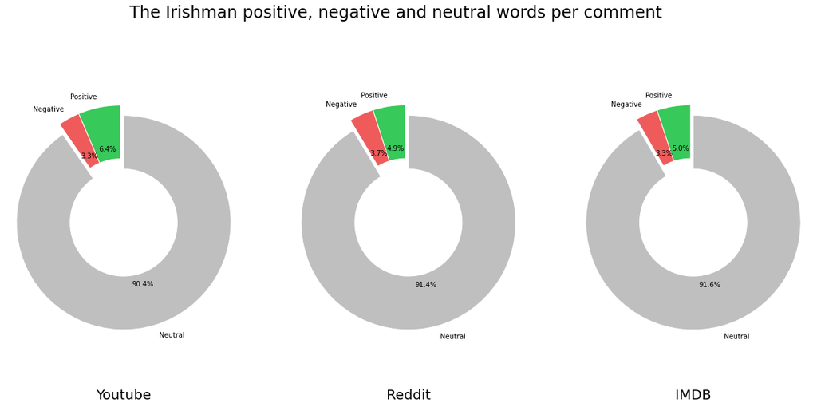

```python
labels = ['YouTube','Reddit','IMDB']
labels2 = ['Positive','Negative','Neutral']
num_words_per_comment = df_irishman['words_per_comment mean']

pos_words = df_irishman['pos_words/coms mean']
pos_proportion = [i / j for i, j in zip(pos_words, num_words_per_comment)]

neg_words = df_irishman['neg_words/coms mean']
neg_proportion = [i / j for i, j in zip(neg_words, num_words_per_comment)]

neu_proportion = [(1-(i + j)) for i, j in zip(pos_proportion, neg_proportion)]

sizes1 = [pos_proportion[0], neg_proportion[0], neu_proportion[0]] #Youtube
sizes2 = [pos_proportion[1], neg_proportion[1], neu_proportion[1]] #Reddit
sizes3 = [pos_proportion[2], neg_proportion[2], neu_proportion[2]] #IMDB

fig, (ax1, ax2, ax3) = plt.subplots(1, 3)
fig.set_figheight(9)
fig.set_figwidth(21)
fig.suptitle('The Irishman positive, negative and neutral words per comment', fontsize=24)
explode = (0, 0, 0.1)
colors = ['#37C959','#EF5B5B','#bfbfbf']
hole_size = 0.5

ax1.pie(sizes1, explode=explode, labels=labels2, colors=colors, autopct='%1.1f%%',
        shadow=False, startangle=90, wedgeprops=dict(width=hole_size, edgecolor='w'))
ax1.axis('equal')# Equal aspect ratio ensures that pie is drawn as a circle.
ax1.set_xlabel('Youtube',fontsize=20)


ax2.pie(sizes2, explode=explode, labels=labels2,  colors=colors, autopct='%1.1f%%',
        shadow=False, startangle=90, wedgeprops=dict(width=hole_size, edgecolor='w'))
ax2.axis('equal')
ax2.set_xlabel('Reddit',fontsize=20)

ax3.pie(sizes3, explode=explode, labels=labels2,  colors=colors, autopct='%1.1f%%',
        shadow=False, startangle=90, wedgeprops=dict(width=hole_size, edgecolor='w'))
ax3.axis('equal')
ax3.set_xlabel('IMDB',fontsize=20)
```

## Once upon a time in Hollywood

```python
import numpy as np
import pandas as pd
import matplotlib.pyplot as plt

df_once = pd.read_csv('/content/drive/Shareddrives/WebIntelligence/DATA/FILM_METRICS/OnceUponMetrics.csv')
df_once.set_index('platrofm', inplace=True, drop=True)
df_once = df_once.fillna(0)
df_once.head(7)
```

| platrofm | num_comments | compound_mean | compound_var | num_pos_com | num_neg_com | num_neu_com | pos_words/coms mean | pos_words/coms var | words_per_comment mean | neg_words/coms mean | neg_words/coms var |
| --- | --- | --- | --- | --- | --- | --- | --- | --- | --- | --- | --- |
| YouTube | 7023 | 0.156 | 0.286 | 3659 | 2079 | 1285 | 1.858 | 6.812 | 27.35 | 1.116 | 3.57 |
| Reddit | 498 | 0.125 | 0.270 | 232 | 142 | 124 | 1.660 | 10.950 | 29.86 | 1.140 | 5.31 |
| IMDB | 325 | 0.460 | 0.500 | 242 | 83 | 0 | 16.690 | 262.030 | 279.62 | 8.150 | 69.24 |

Taking into account the mean compound value of each chapter, we plot the mean and also the variance the values of all the retrieved tweets per episode. The variance is important, as could show up discrepancy in Twitter opinions.

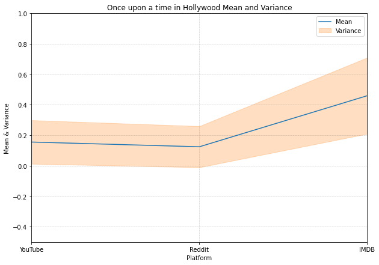

```python
labels = ['YouTube','Reddit','IMDB']

fig = plt.figure(figsize = (10,7))
y_once = df_once['compound_mean'].tolist()
var = df_once['compound_var'].tolist()
x = np.arange(0,3)
var_array = np.array(var)
error = var_array/2
plt.plot(x, y_once, label='Mean')
plt.fill_between(x, y_once-error, y_once+error, color='#ff7f0e', alpha=0.25, label='Variance')
plt.xlabel('Platform')
plt.ylabel('Mean & Variance')
plt.title('Once upon a time in Hollywood Mean and Variance')
plt.grid(linestyle='dotted', linewidth='0.5', color='grey')
plt.axis([0, 2, -0.5, 1])
plt.xticks([0,1,2], labels)
plt.legend()
plt.show()
```

Now we analyze the number of tweets per each "emotion" in each chapter.

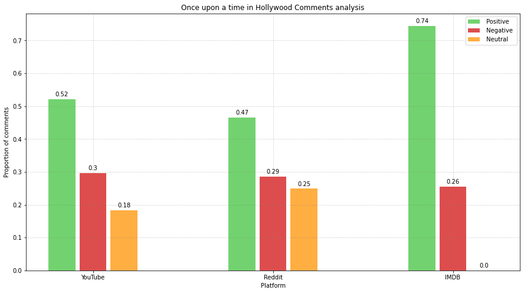

```python
labels = ['YouTube','Reddit','IMDB']
x = np.arange(len(labels))
num_tweets = df_once['num_comments'].to_numpy()
# pos_tweets is the real number
pos_tweets = df_once['num_pos_com'].to_numpy()
# pos_prop is the proportion (pos_tweets/all_tweets)
pos_prop = [i / j for i, j in zip(pos_tweets, num_tweets)]

neg_tweets = df_once['num_neg_com'].to_numpy()
neg_prop = [i / j for i, j in zip(neg_tweets, num_tweets)]

neu_tweets = df_once['num_neu_com'].to_numpy()
neu_prop = [i / j for i, j in zip(neu_tweets, num_tweets)]

fig, ax = plt.subplots()
fig.set_figheight(8)
fig.set_figwidth(15)
width = 0.15
pos_bar = ax.bar(x - width*1.15, pos_prop, width, color='#72D26F',label=' Positive ')
neg_bar = ax.bar(x ,  neg_prop,  width, color='#DD4D4D', label=' Negative ')
neu_bar = ax.bar(x + width*1.15,  neu_prop,  width, color='#FFAE42', label=' Neutral ')
ax.set_ylabel('Proportion of comments')
ax.set_xlabel('Platform')
ax.set_title('Once upon a time in Hollywood Comments analysis')
ax.set_xticks(x)
ax.set_xticklabels(labels)
ax.grid(linestyle='dotted', linewidth='0.5', color='grey')

ax.legend(loc='upper right')

def autolabel(rects):
    """Attach a text label above each bar in *rects*, displaying its height."""
    for rect in rects:
        height = rect.get_height()
        ax.annotate('{}'.format(float(round(height,2))),
                    xy=(rect.get_x() + rect.get_width() / 2, height),
                    xytext=(0, 3),  # 3 points vertical offset
                    textcoords="offset points",
                    ha='center', va='bottom')

autolabel(pos_bar)
autolabel(neg_bar)
autolabel(neu_bar)
```

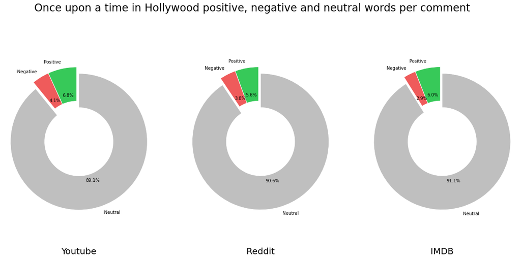

```python
labels = ['YouTube','Reddit','IMDB']
labels2 = ['Positive','Negative','Neutral']
num_words_per_comment = df_once['words_per_comment mean']

pos_words = df_once['pos_words/coms mean']
pos_proportion = [i / j for i, j in zip(pos_words, num_words_per_comment)]

neg_words = df_once['neg_words/coms mean']
neg_proportion = [i / j for i, j in zip(neg_words, num_words_per_comment)]

neu_proportion = [(1-(i + j)) for i, j in zip(pos_proportion, neg_proportion)]

sizes1 = [pos_proportion[0], neg_proportion[0], neu_proportion[0]] #Youtube
sizes2 = [pos_proportion[1], neg_proportion[1], neu_proportion[1]] #Reddit
sizes3 = [pos_proportion[2], neg_proportion[2], neu_proportion[2]] #IMDB

fig, (ax1, ax2, ax3) = plt.subplots(1, 3)
fig.set_figheight(9)
fig.set_figwidth(21)
fig.suptitle('Once upon a time in Hollywood positive, negative and neutral words per comment', fontsize=24)
explode = (0, 0, 0.1)
colors = ['#37C959','#EF5B5B','#bfbfbf']
hole_size = 0.5

ax1.pie(sizes1, explode=explode, labels=labels2, colors=colors, autopct='%1.1f%%',
        shadow=False, startangle=90, wedgeprops=dict(width=hole_size, edgecolor='w'))
ax1.axis('equal')# Equal aspect ratio ensures that pie is drawn as a circle.
ax1.set_xlabel('Youtube',fontsize=20)


ax2.pie(sizes2, explode=explode, labels=labels2,  colors=colors, autopct='%1.1f%%',
        shadow=False, startangle=90, wedgeprops=dict(width=hole_size, edgecolor='w'))
ax2.axis('equal')
ax2.set_xlabel('Reddit',fontsize=20)

ax3.pie(sizes3, explode=explode, labels=labels2,  colors=colors, autopct='%1.1f%%',
        shadow=False, startangle=90, wedgeprops=dict(width=hole_size, edgecolor='w'))
ax3.axis('equal')
ax3.set_xlabel('IMDB',fontsize=20)
```

## The Martian

```python
import numpy as np
import pandas as pd
import matplotlib.pyplot as plt

df_martian = pd.read_csv('/content/drive/Shareddrives/WebIntelligence/DATA/FILM_METRICS/MartianMetrics.csv')
df_martian.set_index('platrofm', inplace=True, drop=True)
df_martian = df_martian.fillna(0)
df_martian.head(7)
```

| platrofm | num_comments | compound_mean | compound_var | num_pos_com | num_neg_com | num_neu_com | pos_words/coms mean | pos_words/coms var | words_per_comment mean | neg_words/coms mean | neg_words/coms var |
| --- | --- | --- | --- | --- | --- | --- | --- | --- | --- | --- | --- |
| YouTube | 2471 | 0.266 | 0.229 | 1415 | 440 | 616 | 1.674 | 6.65 | 23.49 | 0.70 | 2.61 |
| Reddit | 497 | 0.210 | 0.250 | 275 | 135 | 87 | 2.110 | 12.10 | 39.54 | 1.17 | 3.60 |
| IMDB | 325 | 0.550 | 0.480 | 258 | 65 | 2 | 16.750 | 150.65 | 289.93 | 9.15 | 60.87 |

Taking into account the mean compound value of each chapter, we plot the mean and also the variance the values of all the retrieved tweets per episode. The variance is important, as could show up discrepancy in Twitter opinions.

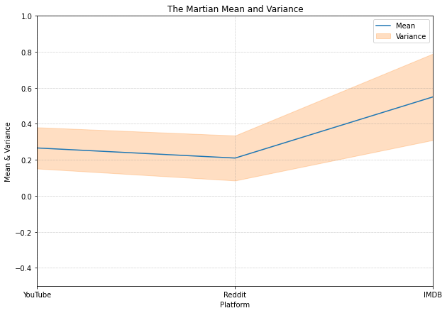

```python
labels = ['YouTube','Reddit','IMDB']

fig = plt.figure(figsize = (10,7))
y_martian = df_martian['compound_mean'].tolist()
var = df_martian['compound_var'].tolist()
x = np.arange(0,3)
var_array = np.array(var)
error = var_array/2
plt.plot(x, y_martian, label='Mean')
plt.fill_between(x, y_martian-error, y_martian+error, color='#ff7f0e', alpha=0.25, label='Variance')
plt.xlabel('Platform')
plt.ylabel('Mean & Variance')
plt.title('The Martian Mean and Variance')
plt.grid(linestyle='dotted', linewidth='0.5', color='grey')
plt.axis([0, 2, -0.5, 1])
plt.xticks([0,1,2], labels)
plt.legend()
plt.show()
```

Now we analyze the number of tweets per each "emotion" in each chapter.

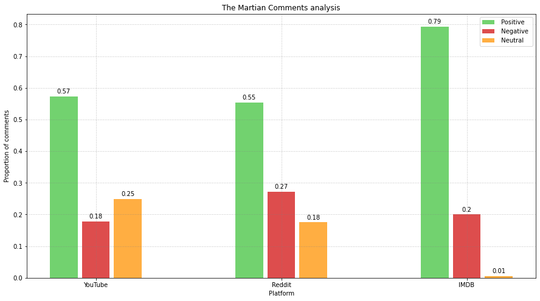

```python
labels = ['YouTube','Reddit','IMDB']
x = np.arange(len(labels))
num_tweets = df_martian['num_comments'].to_numpy()
# pos_tweets is the real number
pos_tweets = df_martian['num_pos_com'].to_numpy()
# pos_prop is the proportion (pos_tweets/all_tweets)
pos_prop = [i / j for i, j in zip(pos_tweets, num_tweets)]

neg_tweets = df_martian['num_neg_com'].to_numpy()
neg_prop = [i / j for i, j in zip(neg_tweets, num_tweets)]

neu_tweets = df_martian['num_neu_com'].to_numpy()
neu_prop = [i / j for i, j in zip(neu_tweets, num_tweets)]

fig, ax = plt.subplots()
fig.set_figheight(8)
fig.set_figwidth(15)
width = 0.15
pos_bar = ax.bar(x - width*1.15, pos_prop, width, color='#72D26F',label=' Positive ')
neg_bar = ax.bar(x ,  neg_prop,  width, color='#DD4D4D', label=' Negative ')
neu_bar = ax.bar(x + width*1.15,  neu_prop,  width, color='#FFAE42', label=' Neutral ')
ax.set_ylabel('Proportion of comments')
ax.set_xlabel('Platform')
ax.set_title('The Martian Comments analysis')
ax.set_xticks(x)
ax.set_xticklabels(labels)
ax.grid(linestyle='dotted', linewidth='0.5', color='grey')

ax.legend(loc='upper right')

def autolabel(rects):
    """Attach a text label above each bar in *rects*, displaying its height."""
    for rect in rects:
        height = rect.get_height()
        ax.annotate('{}'.format(float(round(height,2))),
                    xy=(rect.get_x() + rect.get_width() / 2, height),
                    xytext=(0, 3),  # 3 points vertical offset
                    textcoords="offset points",
                    ha='center', va='bottom')

autolabel(pos_bar)
autolabel(neg_bar)
autolabel(neu_bar)
```

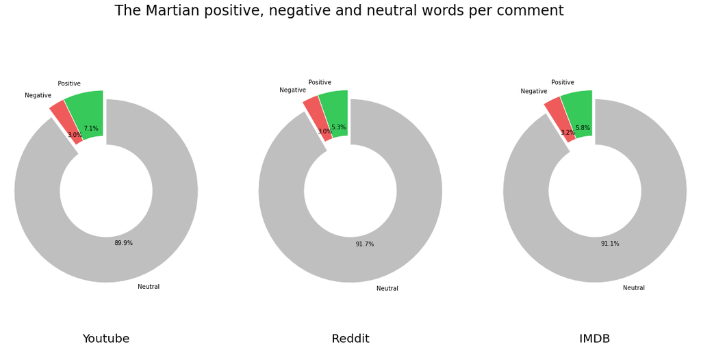

```python
labels = ['YouTube','Reddit','IMDB']
labels2 = ['Positive','Negative','Neutral']
num_words_per_comment = df_martian['words_per_comment mean']

pos_words = df_martian['pos_words/coms mean']
pos_proportion = [i / j for i, j in zip(pos_words, num_words_per_comment)]

neg_words = df_martian['neg_words/coms mean']
neg_proportion = [i / j for i, j in zip(neg_words, num_words_per_comment)]

neu_proportion = [(1-(i + j)) for i, j in zip(pos_proportion, neg_proportion)]

sizes1 = [pos_proportion[0], neg_proportion[0], neu_proportion[0]] #Youtube
sizes2 = [pos_proportion[1], neg_proportion[1], neu_proportion[1]] #Reddit
sizes3 = [pos_proportion[2], neg_proportion[2], neu_proportion[2]] #IMDB

fig, (ax1, ax2, ax3) = plt.subplots(1, 3)
fig.set_figheight(9)
fig.set_figwidth(21)
fig.suptitle('The Martian positive, negative and neutral words per comment', fontsize=24)
explode = (0, 0, 0.1)
colors = ['#37C959','#EF5B5B','#bfbfbf']
hole_size = 0.5

ax1.pie(sizes1, explode=explode, labels=labels2, colors=colors, autopct='%1.1f%%',
        shadow=False, startangle=90, wedgeprops=dict(width=hole_size, edgecolor='w'))
ax1.axis('equal')# Equal aspect ratio ensures that pie is drawn as a circle.
ax1.set_xlabel('Youtube',fontsize=20)


ax2.pie(sizes2, explode=explode, labels=labels2,  colors=colors, autopct='%1.1f%%',
        shadow=False, startangle=90, wedgeprops=dict(width=hole_size, edgecolor='w'))
ax2.axis('equal')
ax2.set_xlabel('Reddit',fontsize=20)

ax3.pie(sizes3, explode=explode, labels=labels2,  colors=colors, autopct='%1.1f%%',
        shadow=False, startangle=90, wedgeprops=dict(width=hole_size, edgecolor='w'))
ax3.axis('equal')
ax3.set_xlabel('IMDB',fontsize=20)
```

## Dunkirk

```python
import numpy as np
import pandas as pd
import matplotlib.pyplot as plt

df_dunkirk = pd.read_csv('/content/drive/Shareddrives/WebIntelligence/DATA/FILM_METRICS/DunkirkMetrics.csv')
df_dunkirk.set_index('platrofm', inplace=True, drop=True)
df_dunkirk = df_dunkirk.fillna(0)
df_dunkirk.head(7)
```

| platrofm | num_comments | compound_mean | compound_var | num_pos_com | num_neg_com | num_neu_com | pos_words/coms mean | pos_words/coms var | words_per_comment mean | neg_words/coms mean | neg_words/coms var |
| --- | --- | --- | --- | --- | --- | --- | --- | --- | --- | --- | --- |
| YouTube | 11147 | 0.100 | 0.29 | 5379 | 3649 | 2120 | 1.99 | 8.84 | 32.75 | 1.37 | 5.24 |
| Reddit | 498 | 0.049 | 0.27 | 209 | 182 | 107 | 1.79 | 7.17 | 36.66 | 1.35 | 4.15 |
| IMDB | 325 | -0.165 | 0.66 | 131 | 194 | 0 | 11.52 | 111.07 | 270.64 | 11.81 | 84.35 |

Taking into account the mean compound value of each chapter, we plot the mean and also the variance the values of all the retrieved tweets per episode. The variance is important, as could show up discrepancy in Twitter opinions.

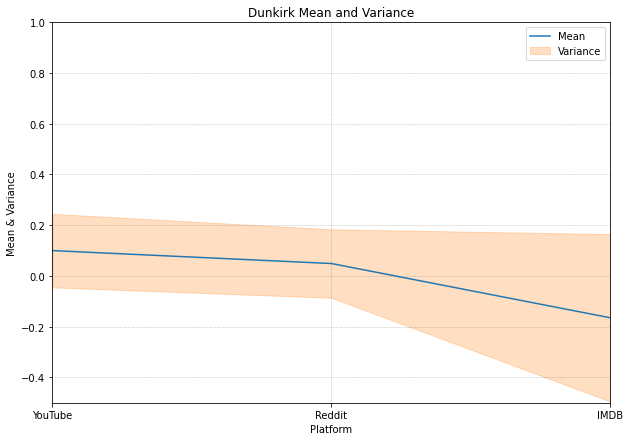

```python
labels = ['YouTube','Reddit','IMDB']

fig = plt.figure(figsize = (10,7))
y_dunkirk = df_dunkirk['compound_mean'].tolist()
var = df_dunkirk['compound_var'].tolist()
x = np.arange(0,3)
var_array = np.array(var)
error = var_array/2
plt.plot(x, y_dunkirk, label='Mean')
plt.fill_between(x, y_dunkirk-error, y_dunkirk+error, color='#ff7f0e', alpha=0.25, label='Variance')
plt.xlabel('Platform')
plt.ylabel('Mean & Variance')
plt.title('Dunkirk Mean and Variance')
plt.grid(linestyle='dotted', linewidth='0.5', color='grey')
plt.axis([0, 2, -0.5, 1])
plt.xticks([0,1,2], labels)
plt.legend()
plt.show()
```

For Dunkirk film, we observe the highest variance of all the analysis. This could mean that the opinions inside IMDB are quite contradictory ones against others, and may be the source of another discussion thread.

Now we analyze the number of tweets per each "emotion" in each chapter.

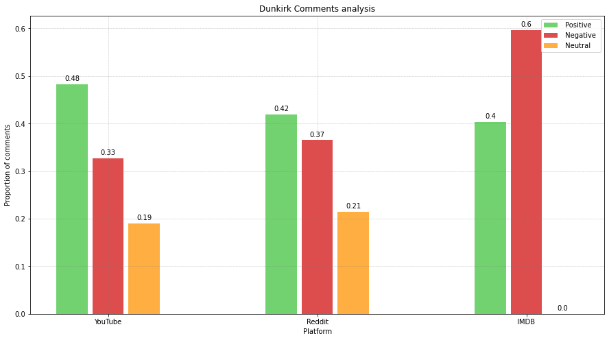

```python
labels = ['YouTube','Reddit','IMDB']
x = np.arange(len(labels))
num_tweets = df_dunkirk['num_comments'].to_numpy()
# pos_tweets is the real number
pos_tweets = df_dunkirk['num_pos_com'].to_numpy()
# pos_prop is the proportion (pos_tweets/all_tweets)
pos_prop = [i / j for i, j in zip(pos_tweets, num_tweets)]

neg_tweets = df_dunkirk['num_neg_com'].to_numpy()
neg_prop = [i / j for i, j in zip(neg_tweets, num_tweets)]

neu_tweets = df_dunkirk['num_neu_com'].to_numpy()
neu_prop = [i / j for i, j in zip(neu_tweets, num_tweets)]

fig, ax = plt.subplots()
fig.set_figheight(8)
fig.set_figwidth(15)
width = 0.15
pos_bar = ax.bar(x - width*1.15, pos_prop, width, color='#72D26F',label=' Positive ')
neg_bar = ax.bar(x ,  neg_prop,  width, color='#DD4D4D', label=' Negative ')
neu_bar = ax.bar(x + width*1.15,  neu_prop,  width, color='#FFAE42', label=' Neutral ')
ax.set_ylabel('Proportion of comments')
ax.set_xlabel('Platform')
ax.set_title('Dunkirk Comments analysis')
ax.set_xticks(x)
ax.set_xticklabels(labels)
ax.grid(linestyle='dotted', linewidth='0.5', color='grey')

ax.legend(loc='upper right')

def autolabel(rects):
    """Attach a text label above each bar in *rects*, displaying its height."""
    for rect in rects:
        height = rect.get_height()
        ax.annotate('{}'.format(float(round(height,2))),
                    xy=(rect.get_x() + rect.get_width() / 2, height),
                    xytext=(0, 3),  # 3 points vertical offset
                    textcoords="offset points",
                    ha='center', va='bottom')

autolabel(pos_bar)
autolabel(neg_bar)
autolabel(neu_bar)
```

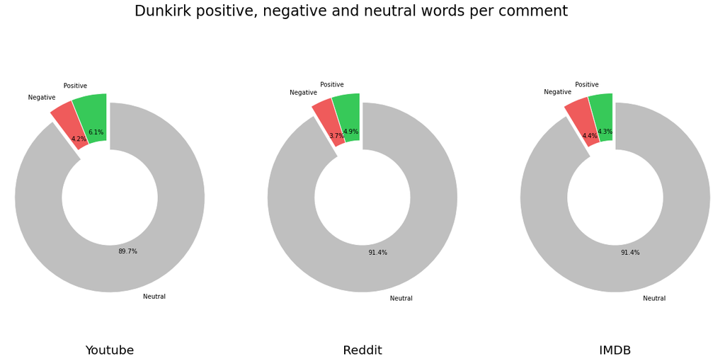

```python
labels = ['YouTube','Reddit','IMDB']
labels2 = ['Positive','Negative','Neutral']
num_words_per_comment = df_dunkirk['words_per_comment mean']

pos_words = df_dunkirk['pos_words/coms mean']
pos_proportion = [i / j for i, j in zip(pos_words, num_words_per_comment)]

neg_words = df_dunkirk['neg_words/coms mean']
neg_proportion = [i / j for i, j in zip(neg_words, num_words_per_comment)]

neu_proportion = [(1-(i + j)) for i, j in zip(pos_proportion, neg_proportion)]

sizes1 = [pos_proportion[0], neg_proportion[0], neu_proportion[0]] #Youtube
sizes2 = [pos_proportion[1], neg_proportion[1], neu_proportion[1]] #Reddit
sizes3 = [pos_proportion[2], neg_proportion[2], neu_proportion[2]] #IMDB

fig, (ax1, ax2, ax3) = plt.subplots(1, 3)
fig.set_figheight(9)
fig.set_figwidth(21)
fig.suptitle('Dunkirk positive, negative and neutral words per comment', fontsize=24)
explode = (0, 0, 0.1)
colors = ['#37C959','#EF5B5B','#bfbfbf']
hole_size = 0.5

ax1.pie(sizes1, explode=explode, labels=labels2, colors=colors, autopct='%1.1f%%',
        shadow=False, startangle=90, wedgeprops=dict(width=hole_size, edgecolor='w'))
ax1.axis('equal')# Equal aspect ratio ensures that pie is drawn as a circle.
ax1.set_xlabel('Youtube',fontsize=20)


ax2.pie(sizes2, explode=explode, labels=labels2,  colors=colors, autopct='%1.1f%%',
        shadow=False, startangle=90, wedgeprops=dict(width=hole_size, edgecolor='w'))
ax2.axis('equal')
ax2.set_xlabel('Reddit',fontsize=20)

ax3.pie(sizes3, explode=explode, labels=labels2,  colors=colors, autopct='%1.1f%%',
        shadow=False, startangle=90, wedgeprops=dict(width=hole_size, edgecolor='w'))
ax3.axis('equal')
ax3.set_xlabel('IMDB',fontsize=20)
```

## Bladerunner 2049

```python
import numpy as np
import pandas as pd
import matplotlib.pyplot as plt

df_blade = pd.read_csv('/content/drive/Shareddrives/WebIntelligence/DATA/FILM_METRICS/BladerunnerMetrics.csv')
df_blade.set_index('platrofm', inplace=True, drop=True)
df_blade = df_blade.fillna(0)
df_blade.head(7)
```

| platrofm | num_comments | compound_mean | compound_var | num_pos_com | num_neg_com | num_neu_com | pos_words/coms mean | pos_words/coms var | words_per_comment mean | neg_words/coms mean | neg_words/coms var |
| --- | --- | --- | --- | --- | --- | --- | --- | --- | --- | --- | --- |
| YouTube | 6512 | 0.257 | 0.256 | 3767 | 1425 | 1320 | 2.091 | 10.69 | 29.89 | 0.925 | 3.70 |
| Reddit | 498 | 0.227 | 0.250 | 287 | 122 | 89 | 2.470 | 20.61 | 44.25 | 1.120 | 4.57 |
| IMDB | 325 | 0.460 | 0.500 | 242 | 83 | 0 | 16.700 | 262.04 | 279.32 | 8.150 | 69.24 |

Taking into account the mean compound value of each chapter, we plot the mean and also the variance the values of all the retrieved tweets per episode. The variance is important, as could show up discrepancy in Twitter opinions.

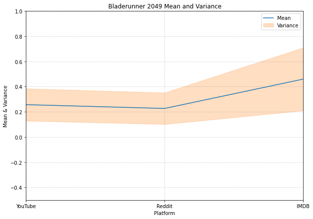

```python
labels = ['YouTube','Reddit','IMDB']

fig = plt.figure(figsize = (10,7))
y_blade = df_blade['compound_mean'].tolist()
var = df_blade['compound_var'].tolist()
x = np.arange(0,3)
var_array = np.array(var)
error = var_array/2
plt.plot(x, y_blade, label='Mean')
plt.fill_between(x, y_blade-error, y_blade+error, color='#ff7f0e', alpha=0.25, label='Variance')
plt.xlabel('Platform')
plt.ylabel('Mean & Variance')
plt.title('Bladerunner 2049 Mean and Variance')
plt.grid(linestyle='dotted', linewidth='0.5', color='grey')
plt.axis([0, 2, -0.5, 1])
plt.xticks([0,1,2], labels)
plt.legend()
plt.show()
```

Now we analyze the number of tweets per each "emotion" in each chapter.

[figure not shown]

```python
labels = ['YouTube','Reddit','IMDB']
x = np.arange(len(labels))
num_tweets = df_dunkirk['num_comments'].to_numpy()
# pos_tweets is the real number
pos_tweets = df_dunkirk['num_pos_com'].to_numpy()
# pos_prop is the proportion (pos_tweets/all_tweets)
pos_prop = [i / j for i, j in zip(pos_tweets, num_tweets)]

neg_tweets = df_dunkirk['num_neg_com'].to_numpy()
neg_prop = [i / j for i, j in zip(neg_tweets, num_tweets)]

neu_tweets = df_dunkirk['num_neu_com'].to_numpy()
neu_prop = [i / j for i, j in zip(neu_tweets, num_tweets)]

fig, ax = plt.subplots()
fig.set_figheight(8)
fig.set_figwidth(15)
width = 0.15
pos_bar = ax.bar(x - width*1.15, pos_prop, width, color='#72D26F',label=' Positive ')
neg_bar = ax.bar(x ,  neg_prop,  width, color='#DD4D4D', label=' Negative ')
neu_bar = ax.bar(x + width*1.15,  neu_prop,  width, color='#FFAE42', label=' Neutral ')
ax.set_ylabel('Proportion of comments')
ax.set_xlabel('Platform')
ax.set_title('Bladerunner 2049 Comments analysis')
ax.set_xticks(x)
ax.set_xticklabels(labels)
ax.grid(linestyle='dotted', linewidth='0.5', color='grey')

ax.legend(loc='upper right')

def autolabel(rects):
    """Attach a text label above each bar in *rects*, displaying its height."""
    for rect in rects:
        height = rect.get_height()
        ax.annotate('{}'.format(float(round(height,2))),
                    xy=(rect.get_x() + rect.get_width() / 2, height),
                    xytext=(0, 3),  # 3 points vertical offset
                    textcoords="offset points",
                    ha='center', va='bottom')

autolabel(pos_bar)
autolabel(neg_bar)
autolabel(neu_bar)
```

[figure not shown]

```python
labels = ['YouTube','Reddit','IMDB']
labels2 = ['Positive','Negative','Neutral']
num_words_per_comment = df_dunkirk['words_per_comment mean']

pos_words = df_blade['pos_words/coms mean']
pos_proportion = [i / j for i, j in zip(pos_words, num_words_per_comment)]

neg_words = df_blade['neg_words/coms mean']
neg_proportion = [i / j for i, j in zip(neg_words, num_words_per_comment)]

neu_proportion = [(1-(i + j)) for i, j in zip(pos_proportion, neg_proportion)]

sizes1 = [pos_proportion[0], neg_proportion[0], neu_proportion[0]] #Youtube
sizes2 = [pos_proportion[1], neg_proportion[1], neu_proportion[1]] #Reddit
sizes3 = [pos_proportion[2], neg_proportion[2], neu_proportion[2]] #IMDB

fig, (ax1, ax2, ax3) = plt.subplots(1, 3)
fig.set_figheight(9)
fig.set_figwidth(21)
fig.suptitle('BladeRunner 2049 positive, negative and neutral words per comment', fontsize=24)
explode = (0, 0, 0.1)
colors = ['#37C959','#EF5B5B','#bfbfbf']
hole_size = 0.5

ax1.pie(sizes1, explode=explode, labels=labels2, colors=colors, autopct='%1.1f%%',
        shadow=False, startangle=90, wedgeprops=dict(width=hole_size, edgecolor='w'))
ax1.axis('equal')# Equal aspect ratio ensures that pie is drawn as a circle.
ax1.set_xlabel('Youtube',fontsize=20)


ax2.pie(sizes2, explode=explode, labels=labels2,  colors=colors, autopct='%1.1f%%',
        shadow=False, startangle=90, wedgeprops=dict(width=hole_size, edgecolor='w'))
ax2.axis('equal')
ax2.set_xlabel('Reddit',fontsize=20)

ax3.pie(sizes3, explode=explode, labels=labels2,  colors=colors, autopct='%1.1f%%',
        shadow=False, startangle=90, wedgeprops=dict(width=hole_size, edgecolor='w'))
ax3.axis('equal')
ax3.set_xlabel('IMDB',fontsize=20)
```

## All films common plot

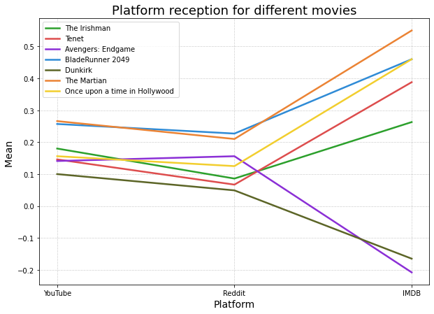

```python
labels = ['YouTube','Reddit','IMDB']

fig = plt.figure(figsize = (10,7))
# var = df_irishman['compound_var'].tolist()
# x = np.arange(0,3)
# var_array = np.array(var)
# error = var_array/2
plt.plot(x, y_irishman, label='The Irishman', color='#2ca02c', linewidth=2.5)
plt.plot(x, y_tenet, label='Tenet ', color='#dd4d4d', linewidth=2.5)
plt.plot(x, y_endgame, label='Avengers: Endgame ', color='#8b2fd6', linewidth=2.5)
plt.plot(x, y_blade, label='BladeRunner 2049 ', color='#2f8bd6', linewidth=2.5)
plt.plot(x, y_dunkirk, label='Dunkirk ', color='#5c6527', linewidth=2.5)
plt.plot(x, y_martian, label='The Martian ', color='#eb8334', linewidth=2.5)
plt.plot(x, y_once, label='Once upon a time in Hollywood ', color='#f2ce2e', linewidth=2.5)
plt.xlabel('Platform', fontsize=14)
plt.ylabel('Mean ', fontsize=14)
plt.title('Platform reception for different movies', fontsize=18)
plt.grid(linestyle='dotted', linewidth='0.5', color='grey')
plt.xticks([0,1,2], labels)
plt.legend()
plt.show()
```

Here we can see reflected what we have been pointing along this notebook: the variance and the behaviour in IMDB is higher than in the other platforms.

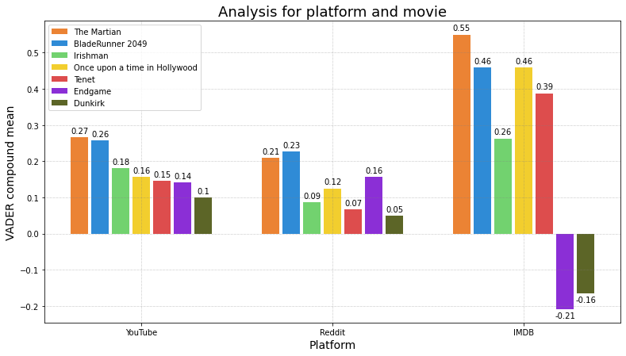

```python
labels = ['YouTube','Reddit','IMDB']
x = np.arange(len(labels))
num_tweets = df_irishman['num_comments'].to_numpy()
# pos_tweets is the real number
pos_tweets = df_irishman['num_pos_com'].to_numpy()
# pos_prop is the proportion (pos_tweets/all_tweets)
pos_prop = [i / j for i, j in zip(pos_tweets, num_tweets)]

neg_tweets = df_irishman['num_neg_com'].to_numpy()
neg_prop = [i / j for i, j in zip(neg_tweets, num_tweets)]

neu_tweets = df_irishman['num_neu_com'].to_numpy()
neu_prop = [i / j for i, j in zip(neu_tweets, num_tweets)]

fig, ax = plt.subplots()
fig.set_figheight(7)
fig.set_figwidth(13)
width = 0.09
space = 1.2

bar_martian = ax.bar(x - 3*width*space,  y_martian,  width, color='#eb8334', label='The Martian')
bar_blade   = ax.bar(x - 2*width*space, y_blade, width, color='#2f8bd6',label='BladeRunner 2049')
bar_irish   = ax.bar(x - width*space, y_irishman, width, color='#72d26f',label='Irishman')
bar_once    = ax.bar(x ,  y_once,  width, color='#f2ce2e', label='Once upon a time in Hollywood')
bar_tenet   = ax.bar(x + width*space,  y_tenet,  width, color='#dd4d4d', label='Tenet')
bar_endgame = ax.bar(x + 2*width*space,  y_endgame,  width, color='#8b2fd6', label='Endgame')
bar_dunkirk = ax.bar(x + 3*width*space, y_dunkirk, width, color='#5c6527',label='Dunkirk')

ax.set_ylabel('VADER compound mean', fontsize=14)
ax.set_xlabel('Platform', fontsize=14)
ax.set_title('Analysis for platform and movie', fontsize=18)
ax.set_xticks(x)
ax.set_xticklabels(labels)
ax.grid(linestyle='dotted', linewidth='0.5', color='grey')

ax.legend(loc='upper left')
# ax.set_tight_layout()
def autolabel(rects):
    """Attach a text label above each bar in *rects*, displaying its height."""
    for rect in rects:
        height = rect.get_height()
        inv = 1
        if height<0:
          inv = -4.5
        ax.annotate('{}'.format(float(round(height,2))),
                    xy=(rect.get_x() + rect.get_width() / 2, height),
                    xytext=(0, 3*inv),  # 3 points vertical offset
                    textcoords="offset points",
                    ha='center', va='bottom')

autolabel(bar_martian)
autolabel(bar_blade)
autolabel(bar_irish)
autolabel(bar_once)
autolabel(bar_tenet)
autolabel(bar_endgame)
autolabel(bar_dunkirk)
```

# Conclusions

Once we have completed the whole analysis for every single film, and computed also some interesting plots for all of them together, we can extract some conclusions:

- All the analysis follow a similar pattern: YouTube and Reddit, more social and less profesionalized platforms, present similar results, with slight differences, but the analysis remains quite aligned. On the other hand, IMDB presents more radical results. This platform reviews are much more polarized and thus have a greater variance.
- Trying to compare the results obtained for IMDB, we checked the IMDB score for this films. This is not so relevant because IMDb indicates that submitted ratings are filtered and weighted in various ways in order to produce a weighted mean that is displayed for each film, series, and so on. It states that filters are used to avoid ballot stuffing; the method is not described in detail to avoid attempts to circumvent it. In fact, it sometimes produces an extreme difference between the weighted average and the arithmetic mean. But, despite this opacity, we obtained the following:
> - The Martian: 8
> - BladeRuner 2049: 8
> - The irishman 2049: 7.9
> - Once upon a time in Hollywood 2049: 7.6
> - Tenet 2049: 7.5
> - Endgame 2049: 8.4
> - Dunkirk 2049: 7.8
- As can be seen, the grades do not correspond directly to what we have extracted. To focus on what could have happened to some films, Avengers: Endgame has the best score regarding official IMDB score, and the worst regarding our study. This could be due to the fact that this film has very sad moments (we don't want to make spoilers), like deaths or tough defeats. If this is commented (we are sure this is commented in IMDB reviews because is a central point of the movie), this words could have biased the sentiment analysis. The same could happen to Dunkirk, a war movie.
- These results may reflect the difference in point of view of people who are familiar with filmmaking and know and follow specific filmmakers and people who simply give their opinion without any previous knowledge, in a purely superficial and subjective basis. Some movies like Once Upon a Time in Hollywood and Tenet could be better considered in IMDB because their filmmakers (Tarantino and Nolan) have a relevant fan base.